# Seazone Code Challenge - Data Science

Lucas Primo Luz

26 janeiro, 2022

Importando pacote

```r
library(dplyr)
library(knitr)
```

Importando os dados

```r
detalhes <- read.csv("desafio_details.csv", sep = ",")
preco <- read.csv("desafio_priceav.csv", sep = ",")
```

Corrigindo a acentuação dos bairros

```r
Encoding(detalhes$suburb) <- "UTF-8"
```

Agrupando as tabelas

```r
dados <- merge(preco,detalhes,by="airbnb_listing_id")
```

## 1.Ordene os bairros em ordem crescente de número de listings

Quantidade de listings por bairro

```r
num_listing <- tapply(dados$suburb, dados$suburb , FUN = length)
```

Ordenando os dados em ordem crescente

```r
( num_listing <- sort(num_listing) )
```

```
##             Centro Lagoa da Conceição             Jurerê       Canasvieiras
##              19182              23431              42857              92186
##           Ingleses
##             176864
```

Gráfico do número de anúncios por bairro

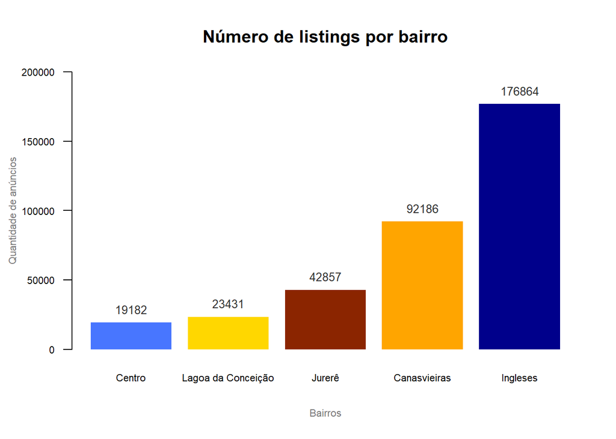

```r
g_num_listing <- barplot(num_listing,
        main = "Número de listings por bairro",
        xlab = "Bairros",
        ylab = "Quantidade de anúncios",
        ylim = c(0,200000),
        las = 1,
        col.lab = "gray47",
        col = c("royalblue1","gold1","orangered4","orange1","darkblue"),
        cex.lab = 0.7, cex.axis = 0.7, cex = 0.7,
        border = NA
)

text(x=c(g_num_listing), y=num_listing, labels=num_listing,
     pos=3, cex = 0.8, col = "gray20")
```

## 2.Ordene os bairros em ordem crescente de faturamento médio dos listings

```r
ocup <- dados[(dados$occupied == 0), ]
```

Calculando o faturamento dos Id’s por bairro

```r
fat_por_bairro = tapply(ocup$price_string,list(ocup$airbnb_listing_id,ocup$suburb),sum)
```

as 5 primeiras linhas do faturamento

```r
kable(head(fat_por_bairro, 5))
```

|  | Canasvieiras | Centro | Ingleses | Jurerê | Lagoa da Conceição |
| --- | --- | --- | --- | --- | --- |
| 108658 | 28000 | NA | NA | NA | NA |
| 128631 | NA | NA | 59980 | NA | NA |
| 279586 | 6320 | NA | NA | NA | NA |
| 333619 | 15054 | NA | NA | NA | NA |
| 344879 | 20421 | NA | NA | NA | NA |

Calculando o faturamento médio para cada Bairro removendo os NA

```r
( med_canasvieiras     = mean(na.omit( fat_por_bairro[,1])) )
```

```
## [1] 20159.48
```

```r
( med_centro           = mean(na.omit( fat_por_bairro[,2])) )
```

```
## [1] 13530.26
```

```r
( med_ingleses         = mean(na.omit( fat_por_bairro[,3])) )
```

```
## [1] 23668.79
```

```r
( med_jerere           = mean(na.omit( fat_por_bairro[,4])) )
```

```
## [1] 26718.41
```

```r
( med_lagoadaconceicao = mean(na.omit( fat_por_bairro[,5])) )
```

```
## [1] 17498.5
```

Agrupando as medias dos bairros

```r
( fat_med = c(med_canasvieiras,med_centro,med_ingleses,med_jerere,med_lagoadaconceicao) )
```

```
## [1] 20159.48 13530.26 23668.79 26718.41 17498.50
```

Ordenando o faturamento dos bairros em ordem crescente

```r
( fat_med = sort( round(fat_med, 2)) )
```

```
## [1] 13530.26 17498.50 20159.48 23668.79 26718.41
```

Gráfico do faturamento médio por bairro

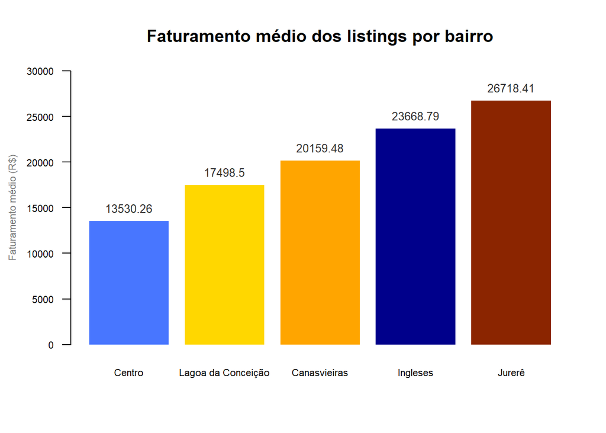

```r
g_fat_med <- barplot(fat_med,
                     main = "Faturamento médio dos listings por bairro",
                     ylab = "Faturamento médio (R$)",
                     ylim = c(0,30000),
                     las = 1,
                     names = c("Centro", "Lagoa da Conceição", "Canasvieiras", "Ingleses", "Jurerê"),
                     col.lab = "gray47",
                     col = c("royalblue1","gold1","orange1","darkblue","orangered4"),
                     cex.lab = 0.7, cex.axis = 0.7, cex = 0.7,
                     border = NA
)

text(x=c(g_fat_med), y=fat_med, labels=fat_med,
     pos=3, cex = 0.8, col = "gray20")
```

## 3.Existem correlações entre as características de um anúncio e seu faturamento?

removendo o NA dos listings ocupados

```r
ocup = na.omit(ocup)
```

Criando matriz do faturamento e seu respectivo id

```r
M_fat <- cbind(tapply(ocup$price_string,sort(ocup$airbnb_listing_id),sum),sort(unique(ocup$airbnb_listing_id)))
```

Nomeando as colunas

```r
colnames(M_fat) <- c("Faturamento", "airbnb_listing_id")
```

Agrupando a matriz do faturamento com os dados gerais ocupados

```r
faturamento <- merge(M_fat,ocup, by="airbnb_listing_id")
```

Para cálculo da correlação vamos unificar os id’s

```r
fat_unico <- distinct(faturamento,
         faturamento$airbnb_listing_id,
         faturamento$Faturamento,
         faturamento$number_of_bedrooms,
         faturamento$number_of_bathrooms,
         faturamento$star_rating,
         faturamento$number_of_reviews)
```

Correlação entre o faturamento e o número de quartos

```r
round(corfatnumquar <- cor(fat_unico$`faturamento$Faturamento`, fat_unico$`faturamento$number_of_bedrooms`), 2)
```

```
## [1] 0.23
```

Correlação entre o faturamento e o número de banheiros

```r
round(corfatnumban <- cor(fat_unico$`faturamento$Faturamento`, fat_unico$`faturamento$number_of_bathrooms`), 2)
```

```
## [1] 0.24
```

Correlação ente o faturamento e a avaliação (número de estrelas)

```r
round(corfatav <- cor(fat_unico$`faturamento$Faturamento`, fat_unico$`faturamento$star_rating`), 2)
```

```
## [1] 0.04
```

Correlação entre o faturamento e a quantidade de comentários

```r
round( corfatnumcom <- cor(fat_unico$`faturamento$Faturamento`, fat_unico$`faturamento$number_of_reviews`), 2)
```

```
## [1] -0.07
```

## 4.Qual a antecedência média das reservas?

Removendo os dados sem reserva

```r
reserv <- dados[(dados$booked_on != "blank"), ]
```

Transformando os dados no formato data

```r
reserv$booked_on <- as.Date(reserv$booked_on)
reserv$date <- as.Date(reserv$date)
```

Adicionando uma coluna na tabela com as antecedências das reservas em números de dias

```r
reserv$antec <- with(reserv, (reserv$date) - (reserv$booked_on))
```

Deixando em 2 casas decimais

```r
round( antec_media <- mean(reserv$antec), 2)
```

```
## Time difference of 32.35 days
```

### a.Esse número é maior ou menor para finais de semana?

Adicionando uma coluna com os dias da semana

```r
reserv$dia_da_semana <- with(reserv, weekdays.Date(reserv$date, abbreviate = FALSE))
```

Cálculo da média da antecedência das reservas sendo sábado e domingo

```r
fim_semana <- tapply(reserv$antec, reserv$dia_da_semana == "domingo" | reserv$dia_da_semana == "sábado", mean)
```

```r
( fim_semana <- round(fim_semana,2) )
```

```
## FALSE  TRUE
## 32.34 32.37
```

Gráfico da antecedência média das reservas nos finais de semana em relação aos dias da semana(segunda à sexta)

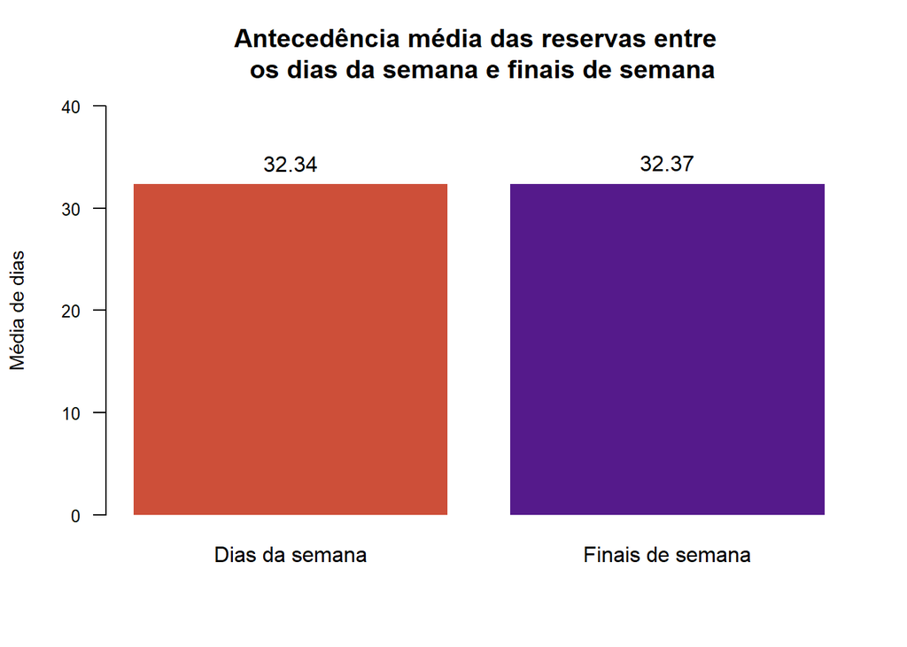

```r
g_fim_semana = barplot(fim_semana,
        main = "Antecedência média das reservas entre \n os dias da semana e finais de semana",
        ylab = "Média de dias",
        ylim = c(0,40),
        las = 1,
        names = c("Dias da semana","Finais de semana"),
        col = c("tomato3","purple4"),
        cex.lab = 0.9, cex.axis = 0.8, cex = 1,
        border = NA
)

text(x=c(g_fim_semana), y=fim_semana, labels=fim_semana, pos=3)
```

Por curiosidade vamos ver se há diferença nas antecedências médias nos por cada dia da semana

Antecedência média por dia da semana

```r
antec_media_por_dia = tapply(reserv$antec, reserv$dia_da_semana , FUN = mean)
```

Ordenando os dados pelo dia em que a antecedência média da reserva é maior

```r
( antec_media_por_dia <- round(sort(antec_media_por_dia), 2))
```

```
##   terça-feira segunda-feira        sábado       domingo  quarta-feira
##         31.18         31.89         32.31         32.43         32.81
##  quinta-feira   sexta-feira
##         32.87         33.00
```

Gráfico da antecedencia média por dia da semana

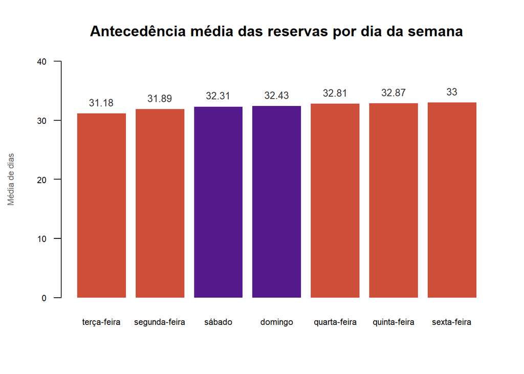

```r
g_antec_media_por_dia <- barplot(antec_media_por_dia,
        main = "Antecedência média das reservas por dia da semana",
        #xlab = "Dia da semana",
        ylab = "Média de dias",
        ylim = c(0,40),
        las = 1,
        col.lab = "gray40",
        col = c("tomato3","tomato3","purple4","purple4","tomato3","tomato3", "tomato3"),
        cex.lab = 0.7, cex.axis = 0.7, cex = 0.7,
        border = NA
)
text(x=c(g_antec_media_por_dia), y=antec_media_por_dia, labels=antec_media_por_dia,
     pos=3, cex = 0.8, col = "gray20")
```